# Webscraping af danske banker

Emil Bønding Wichmann

12. september 2020

## Formålet med webscraping af bankernes side for tilsynsrapporter

Formålet med denne lille web-scraping øvelse er at vise, hvordan en basal model for indhentningen og katalogiseringen af informationer online kan se ud. Der er dermed givetvis mere effektive måder at skrive koden end tilfældet er herunder. Formålet er at vise, hvordan man kan udarbejde datasæt, der indeholder information fra Finanstilsynets redegørelser fra inspektioner af banker (hentet fra pdf’er på bankernes hjemmeside), dato og navn på banken. Billedet herunder viser det endelige resultat. Der er fem variable: 1) en dato-variabel, der er dannet ud fra den nævnte dato i Finanstilsynets brev, 2) en variabel med den tekstbid fra den pågældende pdf, der beskriver påbuddet, 3) navn på banken, 4) link til pdf’en, hvor man kan hente mere information og koble til datasættet og 5) en logisk variabel, der indikerer om der var fundet et påbud i pdf’en.

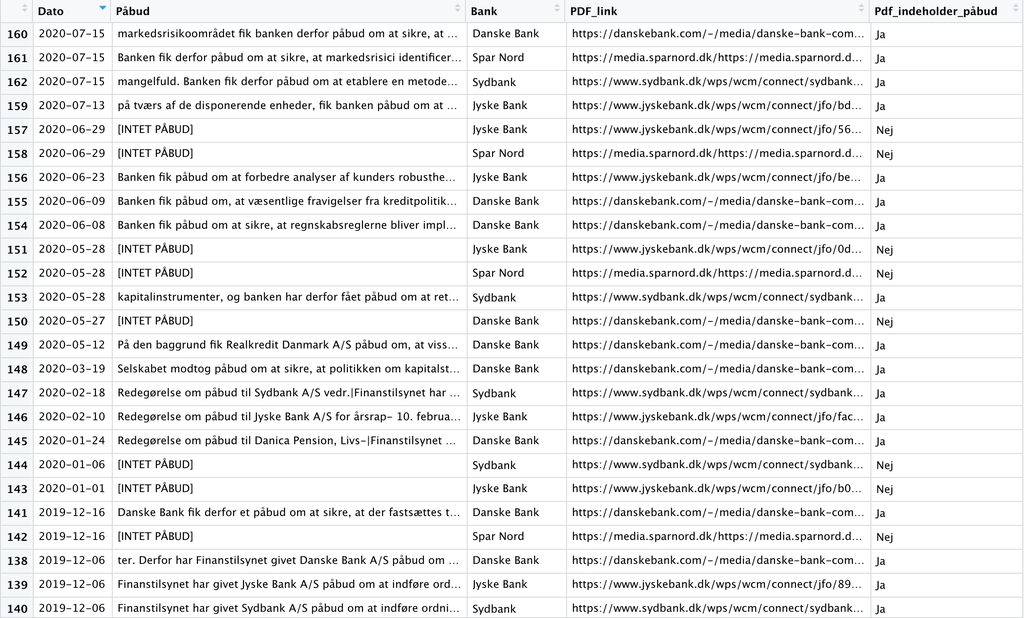

For at nå til ovenstående datasæt skal man igennem følgende trin, som jeg vil gennemgå:

**1. Den automatiske download af pdf’er**  
**2. Ekstrahering af information om inspektionen fra pdf’erne**  
**3. Sammensætningen af informationerne til et overskueligt datasæt.**

Jeg har hentet informationer fra: Danske Bank, Sydbank, Spar Nord og Jyske Bank. Processen leder frem til det datasæt, der er vist i billedet herover.

## Den automatiske download af pdf’er

PDF’er er svært tilgængelige i web-scraping, da de er lukkede dokumenter, der kræver download, for at man kan tilgå dem. Det udelukker, at man kan *scrape* direkte via HTML-koden. Derfor er første skridt at definere hente genvejene til pdf filerne, der gemmer på de informationer om inspektionerne, som jeg er interesseret i. Nedenstående kode definerer, hvilke url’er der indeholder pdf’er (ved større projekter vil man sætte programmet til selv at *scrape* sig vej til de rette informationer vha. af såkaldte *crawlers*). Jeg vælger at indhente alle pdf’er på siden ved at søge på “.pdf” i url’erne. Dette er for at undgå jeg misser mønstre, hvis ord som “temainspektion” eller “redegørelse” ikke giver alle resultater med potentielle påbud. Hagen ved dette er, at man også får “Om os”-sider og årlige rapporter. Som udklippet af de hentede links viser, er det kun genvejen til pdf’erne, der er hentet. Derfor skal bankens hjemmeside også defineres således, at de kan sættes sammen og pdf’erne kan hentes.

```r
#### Danske Bank
url <- 'https://danskebank.com/da/investor-relations/regulering/finanstilsynet'
rapportlinks <- url %>%
  read_html() %>%
  html_nodes('a') %>%
  html_attr('href') %>%
  grep('.pdf', ., value = T)


### Laver links
result <- vector('list', length = length(rapportlinks))
for(j in 1:length(rapportlinks)) {
  base_url <- 'https://danskebank.com'
  rapport_link <- rapportlinks[j]
  rapport_url <- paste0(base_url, rapport_link)
  result[[j]] <- rapport_url

}
```

Ovenstående proces kobler dermed pdf’stien med basislinket, der i dette tilfælde er danskebank.com. Det giver en sti, hvorfra man kan loade tekst fra pdf’en. Samme fremgangsmåde gentages for de øvrige tre banker. Herunder vises de sammensatte url’er for Danske Bank.

```r
head(result)
```

```
## [[1]]
## [1] "https://danskebank.com/-/media/danske-bank-com/file-cloud/2020/7/interim-report---first-half-2020.pdf?rev=3cc29ce7834043e5a5c41f8e3adcd6e7&sc_lang=da"
##
## [[2]]
## [1] "https://danskebank.com/-/media/danske-bank-com/file-cloud/2020/7/interim-report---first-half-2020.pdf?rev=3cc29ce7834043e5a5c41f8e3adcd6e7&sc_lang=da"
##
## [[3]]
## [1] "https://danskebank.com/-/media/danske-bank-com/file-cloud/2020/7/conference-call-presentation---first-half-2020.pdf?rev=c99881e4b3aa44dea219811b99a9bd03&sc_lang=da"
##
## [[4]]
## [1] "https://danskebank.com/-/media/danske-bank-com/file-cloud/2020/7/conference-call-presentation---first-half-2020.pdf?rev=c99881e4b3aa44dea219811b99a9bd03&sc_lang=da"
##
## [[5]]
## [1] "https://danskebank.com/-/media/danske-bank-com/file-cloud/2020/7/fact-book-q2-2020.pdf?rev=84b27b0abbe940fd8f2795f729c838d3&sc_lang=da"
##
## [[6]]
## [1] "https://danskebank.com/-/media/danske-bank-com/file-cloud/2020/7/fact-book-q2-2020.pdf?rev=84b27b0abbe940fd8f2795f729c838d3&sc_lang=da"
```

## Ekstrahering af information om inspektionen fra pdf’erne

Næste skridt er at lave nogle generiske funktioner, der pakker pdf-filerne ud og gør dem læs- og søgbare. Nedenstående to funktioner gør dette. Den første pakker pdf’er ud og deler dem op i sætninger, så det er lettere at søge efter fraser og ord. Den anden funktion pakker pdf’erne ud og gemmer teksten i en enkelt ‘vector’. Dette gør det lettere at finde den øverste dato, som oftest er datoen, som Finanstilsynets redegørelse er dateret til. Den sidstnævnte funktion skal jeg nemlig bruge til at udtrække den specifikke dato, hvor påbuddet er lavet, således jeg kan danne en dato-variabel.

```r
### Laver funktioner til at pakke hhv. datoer og tekst ud
pdf_text_function <- function(x) {
  pdf_text(x) %>%
    readr::read_lines(skip_empty_rows = TRUE) %>%
    replace_white()
}
pdf_text_function_udenreadlines <- function(x) {
  pdf_text(x)%>%
    replace_white()
}
```

Dernæst skal funktionerne appliceres på hver enkelt pdf for hver enkelt bank. Da der fx er over 100 pdf’er på Danske Banks hjemmeside, er det nemmeste at lave et såkaldt ‘loop’, der gentager processen for hver enkelt pdf og gemmer denne i et datasæt genereret til formålet. Herunder er to ‘loop’. Det første loop gennemgår hver enkelt pdf hentet fra Danske Banks hjemmeside for Finanstilsyn og søger efter ord, der indikerer, at der blevet givet et påbud. Derefter gemmer den de sætninger i et nyt datasæt: ‘danskebank’. Det andet loop benytter funktionen henvendt til at finde datoer for redegørelserne. For hver enkelt pdf udtrækker den mønstre, der svarer til formatet: [dato][punktum][mellemrum][ord på mindst 3 bogstaver][mellemrum][tal på 4 cifre]. Dette gemmer den automatisk i det samme datasæt. Det giver et datasæt for Danske Bank, hvor hver enkelt dato for pdf’en har et tilsvarende match med sætninger, hvor et påbud bliver beskrevet. Denne proces gentages for alle banker.

```r
### Applicerer funktionerne på de downloadede links og søger efter mønstre i data, og placerer dem i et datasæt
danskebank <- data_frame( Dato=character(), Påbud=character())
for(i in 1:length(result)){
  danskebank[i,2] <- tryCatch(pdf_text_function(result[[i]])%>%
                    str_subset(pattern = "Banken fik påbud | fik banken påbud | fik påbud | blevet påbudt | har Finanstilsynet påbudt| påbud") %>%
                    str_c(collapse = "|") %>%
                    as_data_frame(), error = function(e) 1)}
for(i in 1:length(result)){
  danskebank[i,1] <- tryCatch(pdf_text_function_udenreadlines(result[[i]]) %>%
                        str_extract(pattern = "[0-9]+\\.\\s[a-z][a-z][a-z]+\\s[0-9][0-9][0-9][0-9]") %>%
                        as_data_frame(), error = function(e) 1)
}
```

Samme proces udføres for Jyske Bank, Spar Nord og Sydbank (koden er identisk og derfor ikke inkluderet), hvorfor jeg efter dette trin har fire datasæt med påbudstekst og dato.

## Sammensætningen af informationerne til et overskueligt datasæt

Nu har jeg fire datasæt med to variable i hver: en variabel for datoen for den enkelte redegørelse og en variabel for ordlyden af påbudet. Disse datasæt skal nu samles, og linket til hver enkelt pdf tilføjes, så man nemt kan finde hele redegørelsen. Derudover skal der laves en variabel, der viser ‘Ja’, hvis den enkelte pdf indeholder et påbud.

Nedenstående kode gør dette for Danske Bank datasættet, og samme proces gentages for alle datasæt.

```r
result_unlist <- unlist(result) %>%
  as_data_frame()
danskebank_test <- danskebank %>%
  mutate(Bank = as.character("Danske Bank")) %>%
  bind_cols(result_unlist)%>%
  mutate(Påbud = ifelse(Påbud == "", NA, Påbud)) %>%
  mutate(Pdf_indeholder_påbud = ifelse(is.na(Påbud), "Nej", "Ja"))%>%
  mutate(Dato=ifelse(Dato==1, NA, Dato))
```

Nu samles alle datasæt og det endelige datasæt får tilsat en lille smule kosmetiske indgreb, der gør det lette at arbejde med. Fx sorteres de observationer, hvor der ikke er en dato væk, da det er generiske sider, der ikke er relevante.

```r
samlet_datasæt <- danskebank_test %>%
  full_join(jyskebank_test)%>%
  full_join(sparnord_test) %>%
  full_join(sydbank_test) %>%
  rename("PDF_link"=value)%>%
  filter(!is.na(Dato))%>%
  arrange(desc(Dato)) %>%
  mutate(Påbud=ifelse(is.na(Påbud), "[INTET PÅBUD]", Påbud))
```

Herunder fremgår det endelige datasæt efter et par finpudsninger. Herfra kan man let scrape flere elementer, der kan tilføje værdi til datasættet. Men formatet er nu overskueligt og lever op til de krav en god dataanalytiker ville stille til struktureringen af et datasæt.

```r
head(samlet_datasæt, n=20)
```

```
## # A tibble: 20 x 5
##    Dato       Påbud               Bank    PDF_link              Pdf_indeholder_…
##    <date>     <chr>               <chr>   <chr>                 <chr>
##  1 2011-09-09 Realkredit Danmark… Danske… https://danskebank.c… Ja
##  2 2017-10-09 [INTET PÅBUD]       Danske… https://danskebank.c… Nej
##  3 2017-10-09 Banken fik derfor … Jyske … https://www.jyskeban… Ja
##  4 2016-05-09 ken har fået påbud… Danske… https://danskebank.c… Ja
##  5 2020-06-09 Banken fik påbud o… Danske… https://danskebank.c… Ja
##  6 2019-01-09 drede forretnings-… Jyske … https://www.jyskeban… Ja
##  7 2015-12-09 [INTET PÅBUD]       Spar N… https://media.sparno… Nej
##  8 2017-09-08 [INTET PÅBUD]       Danske… https://danskebank.c… Nej
##  9 2017-09-08 [INTET PÅBUD]       Jyske … https://www.jyskeban… Nej
## 10 2020-06-08 Banken fik påbud o… Danske… https://danskebank.c… Ja
## 11 2016-02-08 [INTET PÅBUD]       Spar N… https://media.sparno… Nej
## 12 2015-10-06 Finanstilsynet gav… Danske… https://danskebank.c… Ja
## 13 2019-06-06 Finanstilsynet har… Spar N… https://media.sparno… Ja
## 14 2019-06-06 Finanstilsynet har… Sydbank https://www.sydbank.… Ja
## 15 2017-07-06 Finanstilsynet har… Jyske … https://www.jyskeban… Ja
## 16 2017-07-06 Banken fik påbud o… Spar N… https://media.sparno… Ja
## 17 2020-01-06 [INTET PÅBUD]       Sydbank https://www.sydbank.… Nej
## 18 2016-01-06 Finanstilsynet gav… Danske… https://danskebank.c… Ja
## 19 2019-12-06 ter. Derfor har Fi… Danske… https://danskebank.c… Ja
## 20 2019-12-06 Finanstilsynet har… Jyske … https://www.jyskeban… Ja
```

Herunder er et eksempel på en simpel analyse, der viser antallet af gange, der er identificeret en pdf med mindst ét påbud fra perioden 2010-2020.

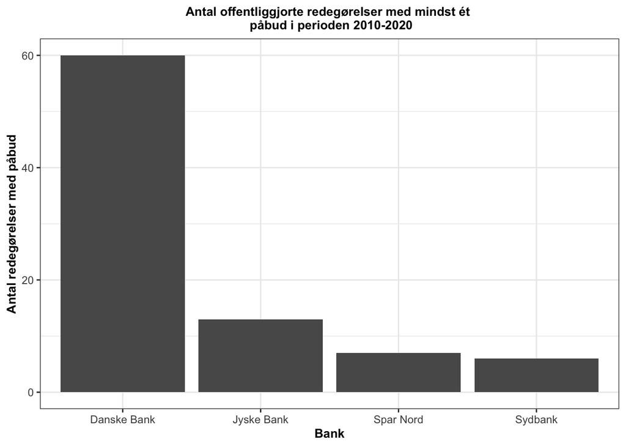

```r
samlet_datasæt %>%
  mutate(Påbud_dummy = ifelse(Pdf_indeholder_påbud=="Ja", 1, 0)) %>%
  ggplot(aes(x=Bank, y=Påbud_dummy)) + geom_bar(stat="identity") +
  scale_y_continuous("Antal redegørelser med påbud") +
  ggtitle("Antal offentliggjorte redegørelser med mindst ét \n påbud i perioden 2010-2020") + theme_bw()+
  theme(
    plot.title = element_text(size=10, face="bold", hjust = 0.5),
    axis.title.x = element_text(size=10, face="bold"),
    axis.title.y = element_text(size=10, face="bold")
  )
```